# Lettuce_growth_days

Zelimkhan

2025-09-22

# Install packages and attach libraries

```r
# install.packages("psych")
# install.packages("lubridate")
# install.packages("purrr")
# install.packages("GGally")
# install.packages("skimr")
# install.packages("Writexl")
# install.packages("corrplot")
library(psych)
library(googlesheets4)
library(tidyr)
library(dplyr)
library(janitor)
library(ggplot2)
library(lubridate)
library(purrr)
library(GGally)
library(readxl)
library(skimr)
library(writexl)
library(corrplot)
```

# Step 1. Ask

## 1.1 Key tasks and Deliverable(s)

### 1.1.1 A clear statement of the business task

Determine how environmental factors (temperature, humidity, and total dissolved solids) influence lettuce growth and maturity time, in order to optimize greenhouse conditions and predict growth outcomes for future growing seasons.

### 1.1.2 Key stakeholders

Managers

### 1.1.3 Smart questions

| N | Type | Questions |
| --- | --- | --- |
| 1 | Specific | Is there a connection between humidity and temperature? |
| 2 | Measurable | How much growth is normal or expected over a one week period? |
| 3 | Action-oriented | If total dissolved solids are increased when growing lettuce, will it shorten the time needed for the plants to reach maturity? |
| 4 | Relevant | Based on the dataset, how can predictions about growth be made given the conditions? |
| 5 | Time - bound | 1) What is the data range for this data set? 2) Do we need an understanding of this data for next season? |

### 1.1.4 Scope of work (SOW)

| N | Deliverables | Timeline | Milestones | Results | What SMART questions will be answered |
| --- | --- | --- | --- | --- | --- |
| 1 | Clean dataset | Day 1 | Completion of data download and preparation | Dataset is clean and usable | - |
| 2 | Exploratory data analysis (EDA) findings (form: spreadsheet, google doc summary) | Day 2 | Completion of EDA - understanding of dataset is formed | EDA highlights room for investigation. Questions were formulated based on the results of EDA. | **Specific:** Is the connection between humidity and temperature **Time - Bound:** What is the data range for this data set? |
| 3 | Engineered features in the form of new columns (examples may include Avg 3 day growth, Growth since day before, etc.) | Day 3 | Completion of feature engineering | New columns engineered to provide more accessible information | **Measurable:** How much growth is normal or expected over a one week period? |
| 4 | Statistical insights | Day 3 | Completion of statistical analysis | Statistical analysis conducted | **Action-oriented:** If total dissolved solids are increased when growing lettuce, will it shorten the time needed for the plants to reach maturity? **Relevant:** Based on the dataset, how can predict… |
| 5 | Visual Aids (images, dashboards) | Days 4-5 | Completion of visualizations | Visualizations created | - |
| 6 | Final report (spreadsheet and PowerPoint) | Day 6-10 | Final report submission | Final report completed | - |

## 1.2 Guiding questions

| N | Questions | Answers |
| --- | --- | --- |
| 1 | What is the problem you are trying to solve? | The challenge lies in understanding (finding patterns) how environmental conditions influence lettuce growth time. This knowledge will help inform decisions to optimize growth cycle. |
| 2 | How can you insights drive business decisions? | Knowing about environmental conditions that impact lettuce growth can help managers decide on construction of an appropriate greenhouse |

# Step 2. Prepare

## 2.1 Key tasks and deliverable(s)

### 2.1.1 Download data and store it appropriately

Data downloaded and stored on my personal computer and Google Drive. Data available at these links: 1) On the work computer: C:/Users/GudievZK/Desktop/GitHub/Google Data Analytics Professional Certificate/1. Ask_Questions_to_Make_Data_Driven_Decisions/lettuce_dataset_SOW.xlsx, sheet = “source_lettuce_dataset 2) On the laptop: /Users/zelimkhan/Desktop/Data/GitHub/Google Data Analytics Professional Certificate/1. Ask_Questions_to_Make_Data_Driven_Decisions/lettuce_dataset_SOW.xlsx 3) On the Google Drive

### 2.1.2 Identify how it’s orginized

The data is organized as a table containing data on 70 plants. The rows contain environmental conditions for each of the 70 plants on each day throughout the growing season. The columns contain information about the plant identifier (Plant_ID) and the following environmental conditions, which were recorded daily for each of the 70 plants throughout the growing season: Date; Temperature (?C); Humidity (%); TDS Value (ppm); pH Level; Growth Days.

### 2.1.3 Sort and filter the data

Data filtered and sorted

### 2.1.4 Determine the credibility of the data

The following methodologies/frameworks were used to determine the credibility of the data: ROCCC; Data Integrity.

#### 2.1.4.1 ROCCC

| N | ROCCC Dimension | Description | Conclusion | Comments |
| --- | --- | --- | --- | --- |
| 1 | Reliable | Source is dependable and consistent. | Watch conclusion below the table | It depends on ROCCC dimensions listed below |
| 2 | Original | We get data from original source (or If we obtained data from a secondary or tertiary source, we could compare and verify it with the primary source) | The data is not original | We do not receive data from the original source, we also cannot identify the original source and have no way to compare it with the original data. However, since the data is provided and used for educ… |
| 3 | Comprehensive | Covers all necessary cases and variables. | It is not possible to determine the level of comprehensiveness of the data | It is logical to assume that data is greatly simplified for educational purposes and does not contain all necessary information needed to solve a business problem. Since it includes the following key … |
| 4 | Current | The data sources aren’t out of date or irrelevant | The data is current | The data can be considered current, even though the observation was conducted in 2023 and the analysis using this information is being carried out in 2025. |
| 5 | Cited | Data source is cited and vetted | The source of the data was not cited or verified. | However, since the data is provided and used for training purposes the data can be used in our work. |

**Reliable:** The data isn’t reliable

**Conclusion on the credibility of the data in accordance with the ROCCC framework:** Data isn’t credible.

#### 2.1.4.2 Data integrity

[output not shown]

**Trustworthiness:** The data isn’t trustworthiness.

**Conclusion on credibility of the data in accordance with the Data integrity conception:** The data isn’t credible.

#### 2.1.4.3 Bias

The dataset appears to come from a controlled educational or research environment, so it may not present all real world farming conditions or varieties of lettuce. However, since it is used for analytical practice rather than policy or production decisions, the risk of bias affecting conclusions is minimal.

**Conclusion on the admissibility of using data:** The data are acceptable for use despite negative findings regarding the credibility of the data in accordance with both the ROCCC framework and the concept of data integrity, as well as the inability to demonstrate the absence of bias, as they are used for educational purposes.

### 2.1.5 A description of all data sourced used

For this analytical task, the “lettuce growth” dataset from Kaggle was used.

## 2.2 Guiding questions

[output not shown]

# Step 3. Process (Stage 1 of EDA: Data Discovery & Profiling)

## 3.1 Key tasks and delivirable(s)

### Load data

```r
df_0 <- read_sheet("https://docs.google.com/spreadsheets/d/1esw9BCXZDO1h4hwuaKowia5eVmflEKTS6NiouamSYA0/edit?gid=723124268#gid=723124268", sheet = "source_lettuce_dataset")

# df_0 <- read_excel("C:/Users/GudievZK/Desktop/GitHub/Google Data Analytics Professional Certificate/1. Ask_Questions_to_Make_Data_Driven_Decisions/lettuce_dataset_SOW.xlsx", sheet = "source_lettuce_dataset")
```

### Table overview

```r
df_0
```

```
## # A tibble: 3,169 × 7
##    Plant_ID Date  `Temperature (°C)` `Humidity (%)` `TDS Value (ppm)` `pH Level`
##       <dbl> <chr>              <dbl>          <dbl>             <dbl>      <dbl>
##  1        1 9/12…               31.2             62               576        6.7
##  2        2 9/12…               31.2             66               657        6.8
##  3        3 9/12…               31.2             69               403        6.6
##  4        4 9/12…               31.2             72               729        6.6
##  5        5 9/12…               31.2             72               738        6.2
##  6        6 9/12…               31.2             57               793        6.4
##  7        7 9/12…               31.2             52               468        6.7
##  8        8 9/12…               31.2             51               768        6.1
##  9        9 9/12…               31.2             80               793        6.6
## 10       10 9/12…               31.2             58               794        6.6
## # ℹ 3,159 more rows
## # ℹ 1 more variable: `Growth Days` <dbl>
```

### Column names

```r
colnames(df_0)
```

```
## [1] "Plant_ID"         "Date"             "Temperature (°C)" "Humidity (%)"
## [5] "TDS Value (ppm)"  "pH Level"         "Growth Days"
```

### Number of rows and columns

```r
dim(df_0)
```

```
## [1] 3169    7
```

### Data types

```r
glimpse(df_0)
```

```
## Rows: 3,169
## Columns: 7
## $ Plant_ID           <dbl> 1, 2, 3, 4, 5, 6, 7, 8, 9, 10, 11, 12, 13, 14, 15, …
## $ Date               <chr> "9/12/2023", "9/12/2023", "9/12/2023", "9/12/2023",…
## $ `Temperature (°C)` <dbl> 31.2, 31.2, 31.2, 31.2, 31.2, 31.2, 31.2, 31.2, 31.…
## $ `Humidity (%)`     <dbl> 62, 66, 69, 72, 72, 57, 52, 51, 80, 58, 66, 64, 51,…
## $ `TDS Value (ppm)`  <dbl> 576, 657, 403, 729, 738, 793, 468, 768, 793, 794, 4…
## $ `pH Level`         <dbl> 6.7, 6.8, 6.6, 6.6, 6.2, 6.4, 6.7, 6.1, 6.6, 6.6, 6…
## $ `Growth Days`      <dbl> 41, 41, 41, 41, 41, 41, 41, 41, 41, 41, 41, 41, 41,…
```

### Data classes

```r
sapply(df_0, class)
```

```
##         Plant_ID             Date Temperature (°C)     Humidity (%)
##        "numeric"      "character"        "numeric"        "numeric"
##  TDS Value (ppm)         pH Level      Growth Days
##        "numeric"        "numeric"        "numeric"
```

### Checking completeness

Number of missing values in each column

```r
colSums(is.na(df_0))
```

```
##         Plant_ID             Date Temperature (°C)     Humidity (%)
##                0                0                0                0
##  TDS Value (ppm)         pH Level      Growth Days
##                0                0                0
```

### Checking duplicates

Number of duplicate values in each column

```r
sapply(df_0, function(x) sum(duplicated(x)))
```

```
##         Plant_ID             Date Temperature (°C)     Humidity (%)
##             3099             3121             3071             3138
##  TDS Value (ppm)         pH Level      Growth Days
##             2768             3160             3121
```

### Checking uniqueness

Number of unique rows

```r
distinct(df_0) %>% dim()
```

```
## [1] 3169    7
```

Number of unique values in each column

```r
sapply(df_0, function(x) sum(n_distinct(x)))
```

```
##         Plant_ID             Date Temperature (°C)     Humidity (%)
##               70               48               98               31
##  TDS Value (ppm)         pH Level      Growth Days
##              401                9               48
```

### Transorm data

Convert Date column from character into date Creating new data frame

```r
df <- df_0
```

```r
df$Date <- mdy(df$Date)
```

Convert Plant_ID column from numeric into factor

```r
df$Plant_ID <- as.factor(df$Plant_ID)
```

Clean names

```r
df <- clean_names(df)
```

### Checking data after transormation

#### Table overview

```r
df %>% arrange(date)
```

```
## # A tibble: 3,169 × 7
##    plant_id date       temperature_c humidity_percent tds_value_ppm p_h_level
##    <fct>    <date>             <dbl>            <dbl>         <dbl>     <dbl>
##  1 1        2023-08-03          33.4               53           582       6.4
##  2 2        2023-08-03          33.4               74           586       6.1
##  3 3        2023-08-03          33.4               51           667       6.2
##  4 4        2023-08-03          33.4               62           547       6.7
##  5 5        2023-08-03          33.4               67           651       6.3
##  6 6        2023-08-03          33.4               66           795       6.1
##  7 7        2023-08-03          33.4               74           459       6.5
##  8 8        2023-08-03          33.4               76           650       6
##  9 9        2023-08-03          33.4               72           693       6.4
## 10 10       2023-08-03          33.4               66           503       6.5
## # ℹ 3,159 more rows
## # ℹ 1 more variable: growth_days <dbl>
```

#### Checking completeness after transformation

```r
colSums(is.na(df))
```

```
##         plant_id             date    temperature_c humidity_percent
##                0                0                0                0
##    tds_value_ppm        p_h_level      growth_days
##                0                0                0
```

#### Checking data stricture after transformation

```r
str(df)
```

```
## tibble [3,169 × 7] (S3: tbl_df/tbl/data.frame)
##  $ plant_id        : Factor w/ 70 levels "1","2","3","4",..: 1 2 3 4 5 6 7 8 9 10 ...
##  $ date            : Date[1:3169], format: "2023-09-12" "2023-09-12" ...
##  $ temperature_c   : num [1:3169] 31.2 31.2 31.2 31.2 31.2 31.2 31.2 31.2 31.2 31.2 ...
##  $ humidity_percent: num [1:3169] 62 66 69 72 72 57 52 51 80 58 ...
##  $ tds_value_ppm   : num [1:3169] 576 657 403 729 738 793 468 768 793 794 ...
##  $ p_h_level       : num [1:3169] 6.7 6.8 6.6 6.6 6.2 6.4 6.7 6.1 6.6 6.6 ...
##  $ growth_days     : num [1:3169] 41 41 41 41 41 41 41 41 41 41 ...
```

## 3.2 Guiding questions

[output not shown]

#### Interpretation of the 1st stage EDA: Data Discovery & Profiling

**Purpose and Approach**

This stage focused on initial understanding and validation of the lettuce dataset to answer two main questions:

What does the data contain?

Is the data clean and ready for analysis?

**📄 Findings**

Dataset structure: The table contained 3,169 rows and 7 columns, representing multiple measurements for 70 individual plants across 48 observation days. Columns included: plant_id, date, temperature_c, humidity_percent, tds_value_ppm, p_h_level and growth_days

**Uniqueness and duplication checks:**

No duplicated rows were found (distinct(df_0) returned 3,169 unique rows).

**Data type consistency:**

The “date” column was initially stored as a character type and was converted to a proper Date format using mdy().

The “plant_id” column was converted from numeric to factor, which correctly represents categorical identifiers.

Column names were standardized with clean_names() for consistent syntax.

**Quality assessment:**

No missing values were reported.

The only detected issue before transformation was inconsistent date formatting.

After cleaning, all variables were in the correct type and ready for deeper analysis.

# Analyze

## Stage 2 of EDA: Univariate analysis (“Understanding individual variables” phase)

#### Summary statistics

Summary statistics using skim function

```r
skim(df) %>%
  mutate(across(where(is.numeric), ~ round(.x, 2)))
```

Data summary

| Name | df |
| --- | --- |
| Number of rows | 3169 |
| Number of columns | 7 |
| _______________________ |  |
| Column type frequency: |  |
| Date | 1 |
| factor | 1 |
| numeric | 5 |
| ________________________ |  |
| Group variables | None |

**Variable type: Date**

| skim_variable | n_missing | complete_rate | min | max | median | n_unique |
| --- | --- | --- | --- | --- | --- | --- |
| date | 0 | 1 | 2023-08-03 | 2023-09-19 | 2023-08-25 | 48 |

**Variable type: factor**

| skim_variable | n_missing | complete_rate | ordered | n_unique | top_counts |
| --- | --- | --- | --- | --- | --- |
| plant_id | 0 | 1 | FALSE | 70 | 4: 48, 55: 48, 3: 47, 7: 47 |

**Variable type: numeric**

| skim_variable | n_missing | complete_rate | mean | sd | p0 | p25 | p50 | p75 | p100 | hist |
| --- | --- | --- | --- | --- | --- | --- | --- | --- | --- | --- |
| temperature_c | 0 | 1 | 28.14 | 4.67 | 18 | 23.6 | 30.2 | 31.5 | 33.5 | ▂▂▁▅▇ |
| humidity_percent | 0 | 1 | 64.87 | 8.99 | 50 | 57.0 | 65.0 | 73.0 | 80.0 | ▇▆▆▇▆ |
| tds_value_ppm | 0 | 1 | 598.05 | 115.71 | 400 | 498.0 | 593.0 | 699.0 | 800.0 | ▇▇▇▇▇ |
| p_h_level | 0 | 1 | 6.40 | 0.23 | 6 | 6.2 | 6.4 | 6.6 | 6.8 | ▆▇▃▇▆ |
| growth_days | 0 | 1 | 23.14 | 13.08 | 1 | 12.0 | 23.0 | 34.0 | 48.0 | ▇▇▇▇▆ |

Summary statistics using summary function

```r
summary(df)
```

```
##     plant_id         date            temperature_c   humidity_percent
##  4      :  48   Min.   :2023-08-03   Min.   :18.00   Min.   :50.00
##  55     :  48   1st Qu.:2023-08-14   1st Qu.:23.60   1st Qu.:57.00
##  3      :  47   Median :2023-08-25   Median :30.20   Median :65.00
##  7      :  47   Mean   :2023-08-25   Mean   :28.14   Mean   :64.87
##  11     :  47   3rd Qu.:2023-09-05   3rd Qu.:31.50   3rd Qu.:73.00
##  48     :  47   Max.   :2023-09-19   Max.   :33.50   Max.   :80.00
##  (Other):2885
##  tds_value_ppm   p_h_level      growth_days
##  Min.   :400   Min.   :6.000   Min.   : 1.00
##  1st Qu.:498   1st Qu.:6.200   1st Qu.:12.00
##  Median :593   Median :6.400   Median :23.00
##  Mean   :598   Mean   :6.399   Mean   :23.14
##  3rd Qu.:699   3rd Qu.:6.600   3rd Qu.:34.00
##  Max.   :800   Max.   :6.800   Max.   :48.00
##
```

#### Examine distribution and detecting outliers

Examine distribution plotting histograms

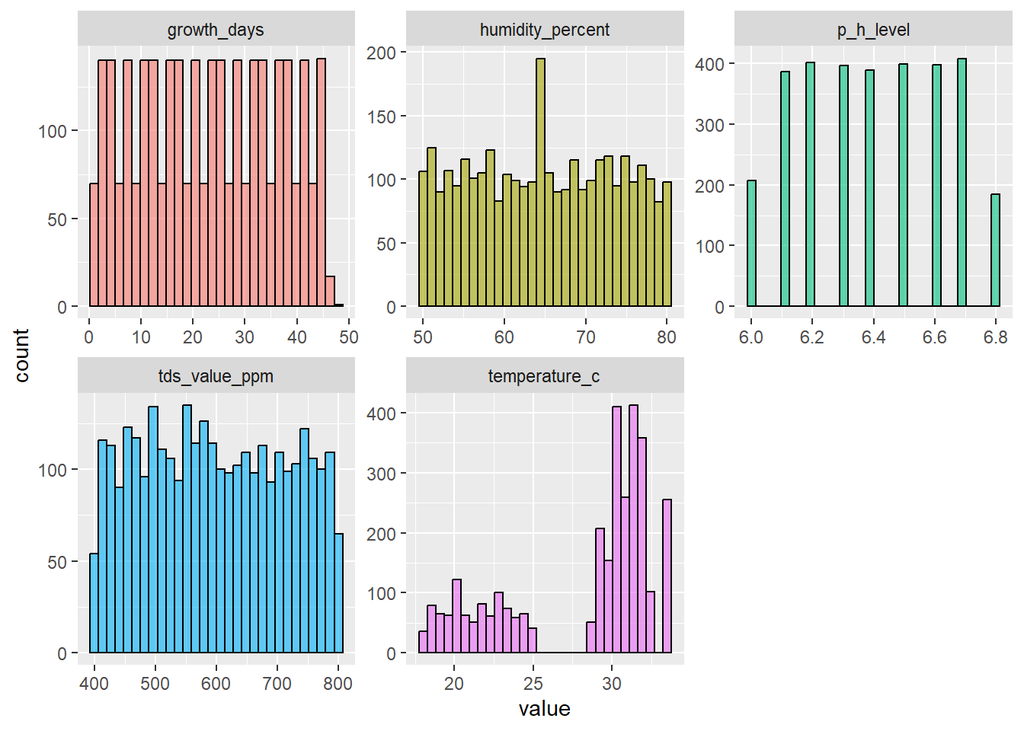

```r
df %>% select(where(is.numeric)) %>%
  pivot_longer(everything(),
               names_to = "variable",
               values_to = "value") %>%
  ggplot(aes(x = value, fill = variable)) +
  geom_histogram(bins = 30, alpha = 0.6, color = "black", na.rm = TRUE) +
  facet_wrap(~ variable, scales = "free", ncol = 3) +
# theme_minimal() +
  guides(fill = "none")
```

Detect outliers plotting boxplots

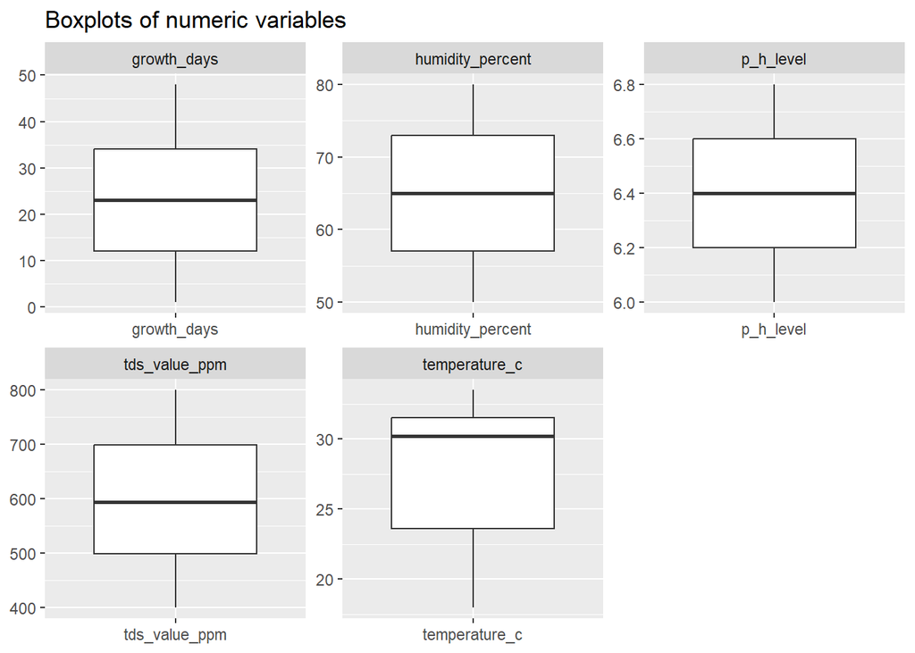

```r
df %>% select(where(is.numeric)) %>%
  pivot_longer(everything(),
               names_to = "variable",
               values_to = "value") %>%
  ggplot(aes(x = variable, y = value)) +
  geom_boxplot(outliers.alpha = 0.35) +
  labs(x = NULL, y = NULL, title = "Boxplots of numeric variables") +
  facet_wrap(~ variable, scales = "free", ncol = 3) +
  # theme_minimal() +
  guides(fill = "none")
```

#### Interpretation of the 2d stage EDA: Univariate analysis

**🎯 Purpose**

This step examined each variable independently to describe its distribution, variation, and potential outliers.

**📈 Summary Statistics**

Rows: 3,169

Columns: 7

Variable types: 1 Date (date), 1 Factor (plant_id), 5 Numeric (temperature_c, humidity_percent, tds_value_ppm, p_h_level, growth_days).

Missing data: 0 across all columns.

📅 Date Variable

Range: 2023-08-03 → 2023-09-19 (48 unique days). → Represents about 7 weeks of continuous monitoring.

🪴 Plant ID

70 unique plants, each measured several times (roughly 45 observations per plant). → Confirms the dataset’s panel/time-series nature.

**🔢 Numeric Variables**

[output not shown]

## 3.3 Bivariate/Multivariate analysis (“Understanding relationships” phase)

```r
df %>% select(where(is.numeric)) %>%
  cor(use = "complete.obs") %>% round(2)
```

```
##                  temperature_c humidity_percent tds_value_ppm p_h_level
## temperature_c             1.00             0.03         -0.01      0.01
## humidity_percent          0.03             1.00         -0.01      0.02
## tds_value_ppm            -0.01            -0.01          1.00     -0.01
## p_h_level                 0.01             0.02         -0.01      1.00
## growth_days              -0.07            -0.01         -0.02      0.00
##                  growth_days
## temperature_c          -0.07
## humidity_percent       -0.01
## tds_value_ppm          -0.02
## p_h_level               0.00
## growth_days             1.00
```

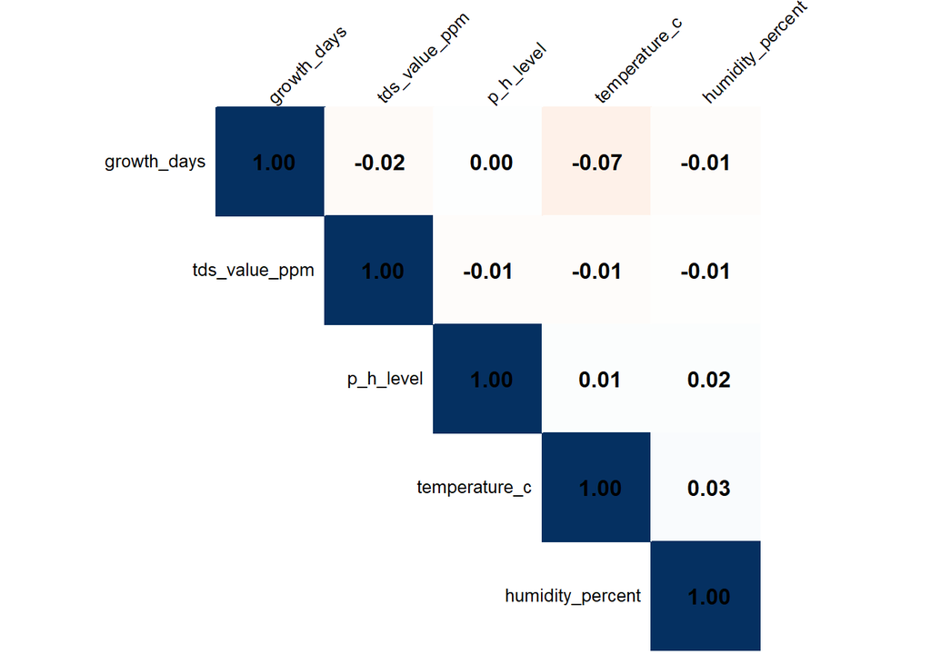

```r
df %>% select(where(is.numeric)) %>%
  cor(use = "complete.obs") %>%
  corrplot::corrplot(method = "color",
                     type = "upper",
                     order = "hclust",
                     addCoef.col = "black",
                     tl.cex = 0.8,
                     tl.col = "black",
                     tl.srt = 45,
                     cl.pos = "n")
```

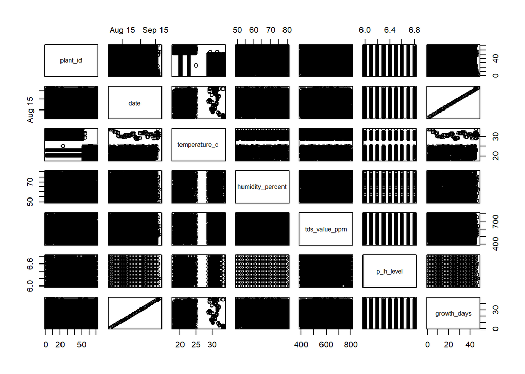

```r
pairs(df)
```

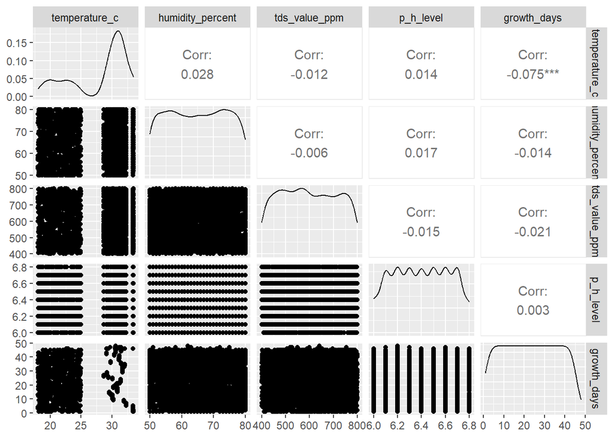

```r
df %>% select(-plant_id, -date) %>%
  ggpairs()
```

**🎯 Purpose**

This stage examined how environmental variables relate to each other and to the target variable — Growth Days.

**💡 Interpretation of Correlations**

All correlations are weak (|r| < 0.1) — no strong linear dependencies among variables.

Slight negative correlation between temperature_c and growth_days (-0.07) could indicate that higher temperatures may slightly accelerate early growth, reducing total growth duration.

Other environmental factors (humidity_percent, tds_value_ppm, p_h_level) show minimal direct relationships to growth time.

The correlation plot confirms overall independence of predictors, meaning multicollinearity is not a concern.

**🧠 General Interpretation**

The weak correlations suggest lettuce growth in this dataset is not linearly dominated by any single factor — growth may depend on nonlinear or combined environmental effects (e.g., optimal ranges rather than simple linear relationships).

These findings justify future modeling efforts (like regression or machine learning) to explore interactions or thresholds rather than direct proportional effects.

All statistics by plant id

```r
all_stats_by_id <- df %>% group_by(plant_id) %>%
  summarise(
            date_min = min(date),
            date_mean = mean(date),
            date_median = median(date),
            date_max = max(date),
            temperature_c_min = min(temperature_c),
            temperature_c_q1 = quantile(temperature_c, 0.25),
            temperature_c_mean = mean(temperature_c),
            temperature_c_median = median(temperature_c),
            temperature_c_sd = sd(temperature_c),
            temperature_c_q3 = quantile(temperature_c, 0.75),
            temperature_c_max = max(temperature_c),
            humidity_percent_min = min(humidity_percent),
            humidity_percent_q1 = quantile(humidity_percent, 0.25),
            humidity_percent_mean = mean(humidity_percent),
            humidity_percent_median = median(humidity_percent),
            humidity_percent_sd = sd(humidity_percent),
            humidity_percent_q3 = quantile(humidity_percent, 0.75),
            humidity_percent_max = max(humidity_percent),
            tds_value_ppm_min = min(tds_value_ppm),
            tds_value_ppm_q1 = quantile(tds_value_ppm, 0.25),
            tds_value_ppm_mean = mean(tds_value_ppm),
            tds_value_ppm_median = median(tds_value_ppm),
            tds_value_ppm_sd = sd(tds_value_ppm),
            tds_value_ppm_q3 = quantile(tds_value_ppm, 0.75),
            tds_value_ppm_max = max(tds_value_ppm),
            p_h_level_min = min(p_h_level),
            p_h_level_q1 = quantile(p_h_level, 0.25),
            p_h_level_mean = mean(p_h_level),
            p_h_level_median = median(p_h_level),
            p_h_level_sd = sd(p_h_level),
            p_h_level_q3 = quantile(p_h_level, 0.75),
            p_h_level_max = max(p_h_level),
            growth_days_min = min(growth_days),
            growth_days_q1 = quantile(growth_days, 0.25),
            growth_days_mean = mean(growth_days),
            growth_days_median = median(growth_days),
            growth_days_sd = sd(growth_days),
            growth_days_q3 = quantile(growth_days, 0.75),
            growth_days_max = max(growth_days)
  ) %>%
  mutate(
    across(where(is.numeric), ~ round(.x, 2))
         )

all_stats_by_id
```

```
## # A tibble: 70 × 40
##    plant_id date_min   date_mean  date_median date_max   temperature_c_min
##    <fct>    <date>     <date>     <date>      <date>                 <dbl>
##  1 1        2023-08-03 2023-08-25 2023-08-25  2023-09-16              20.1
##  2 2        2023-08-03 2023-08-25 2023-08-25  2023-09-16              20.1
##  3 3        2023-08-03 2023-08-26 2023-08-26  2023-09-18              20.1
##  4 4        2023-08-03 2023-08-26 2023-08-26  2023-09-19              20.1
##  5 5        2023-08-03 2023-08-25 2023-08-25  2023-09-16              20.1
##  6 6        2023-08-03 2023-08-25 2023-08-25  2023-09-16              20.1
##  7 7        2023-08-03 2023-08-26 2023-08-26  2023-09-18              20.1
##  8 8        2023-08-03 2023-08-25 2023-08-25  2023-09-16              20.1
##  9 9        2023-08-03 2023-08-25 2023-08-25  2023-09-17              20.1
## 10 10       2023-08-03 2023-08-25 2023-08-25  2023-09-16              20.1
## # ℹ 60 more rows
## # ℹ 34 more variables: temperature_c_q1 <dbl>, temperature_c_mean <dbl>,
## #   temperature_c_median <dbl>, temperature_c_sd <dbl>, temperature_c_q3 <dbl>,
## #   temperature_c_max <dbl>, humidity_percent_min <dbl>,
## #   humidity_percent_q1 <dbl>, humidity_percent_mean <dbl>,
## #   humidity_percent_median <dbl>, humidity_percent_sd <dbl>,
## #   humidity_percent_q3 <dbl>, humidity_percent_max <dbl>, …
```

Summary of all statistics by plant id

```r
all_stats_by_id %>% summary()
```

```
##     plant_id     date_min            date_mean           date_median
##  1      : 1   Min.   :2023-08-03   Min.   :2023-08-25   Min.   :2023-08-25
##  2      : 1   1st Qu.:2023-08-03   1st Qu.:2023-08-25   1st Qu.:2023-08-25
##  3      : 1   Median :2023-08-03   Median :2023-08-25   Median :2023-08-25
##  4      : 1   Mean   :2023-08-03   Mean   :2023-08-25   Mean   :2023-08-25
##  5      : 1   3rd Qu.:2023-08-03   3rd Qu.:2023-08-25   3rd Qu.:2023-08-25
##  6      : 1   Max.   :2023-08-03   Max.   :2023-08-26   Max.   :2023-08-26
##  (Other):64
##     date_max          temperature_c_min temperature_c_q1 temperature_c_mean
##  Min.   :2023-09-16   Min.   :18.00     Min.   :18.80    Min.   :21.04
##  1st Qu.:2023-09-16   1st Qu.:18.32     1st Qu.:20.25    1st Qu.:21.94
##  Median :2023-09-16   Median :20.10     Median :30.10    Median :30.63
##  Mean   :2023-09-16   Mean   :19.56     Mean   :27.27    Mean   :28.14
##  3rd Qu.:2023-09-16   3rd Qu.:20.10     3rd Qu.:30.10    3rd Qu.:30.63
##  Max.   :2023-09-19   Max.   :20.10     Max.   :30.10    Max.   :30.67
##
##  temperature_c_median temperature_c_sd temperature_c_q3 temperature_c_max
##  Min.   :20.75        Min.   :1.810    Min.   :22.2     Min.   :24.60
##  1st Qu.:22.23        1st Qu.:2.277    1st Qu.:23.8     1st Qu.:26.65
##  Median :30.90        Median :2.380    Median :31.7     Median :33.50
##  Mean   :28.34        Mean   :2.301    Mean   :29.4     Mean   :31.25
##  3rd Qu.:30.90        3rd Qu.:2.380    3rd Qu.:31.7     3rd Qu.:33.50
##  Max.   :31.10        Max.   :3.160    Max.   :31.7     Max.   :33.50
##
##  humidity_percent_min humidity_percent_q1 humidity_percent_mean
##  Min.   :50.00        Min.   :53.00       Min.   :62.62
##  1st Qu.:50.00        1st Qu.:56.00       1st Qu.:63.71
##  Median :50.00        Median :57.00       Median :64.82
##  Mean   :50.19        Mean   :57.39       Mean   :64.88
##  3rd Qu.:50.00        3rd Qu.:59.00       3rd Qu.:65.81
##  Max.   :51.00        Max.   :62.50       Max.   :68.68
##
##  humidity_percent_median humidity_percent_sd humidity_percent_q3
##  Min.   :61.00           Min.   : 7.050      Min.   :68.00
##  1st Qu.:63.00           1st Qu.: 8.533      1st Qu.:71.00
##  Median :65.00           Median : 9.060      Median :72.88
##  Mean   :64.89           Mean   : 8.959      Mean   :72.29
##  3rd Qu.:66.00           3rd Qu.: 9.287      3rd Qu.:74.00
##  Max.   :72.00           Max.   :10.290      Max.   :76.00
##
```

[output cut: 33 more lines]

```
##  Min.   :12.00   Min.   :23.00    Min.   :23.00      Min.   :13.13
##  1st Qu.:12.00   1st Qu.:23.00    1st Qu.:23.00      1st Qu.:13.13
##  Median :12.00   Median :23.00    Median :23.00      Median :13.13
##  Mean   :12.07   Mean   :23.13    Mean   :23.14      Mean   :13.21
##  3rd Qu.:12.00   3rd Qu.:23.00    3rd Qu.:23.00      3rd Qu.:13.13
##  Max.   :12.75   Max.   :24.50    Max.   :24.50      Max.   :14.00
##
##  growth_days_q3  growth_days_max
##  Min.   :34.00   Min.   :45.00
##  1st Qu.:34.00   1st Qu.:45.00
##  Median :34.00   Median :45.00
##  Mean   :34.20   Mean   :45.26
##  3rd Qu.:34.00   3rd Qu.:45.00
##  Max.   :36.25   Max.   :48.00
##
```

Statistics (basic) by plant id

```r
all_stats_by_id %>%
  select(plant_id,
         temperature_c_mean,
         humidity_percent_mean,
         tds_value_ppm_mean,
         p_h_level_mean,
         growth_days_max)
```

```
## # A tibble: 70 × 6
##    plant_id temperature_c_mean humidity_percent_mean tds_value_ppm_mean
##    <fct>                 <dbl>                 <dbl>              <dbl>
##  1 1                      30.6                  64.0               615.
##  2 2                      30.6                  64.6               597.
##  3 3                      30.6                  68.7               620.
##  4 4                      30.6                  63.4               598.
##  5 5                      30.6                  65.1               577.
##  6 6                      30.6                  64.4               614.
##  7 7                      30.6                  64.1               608.
##  8 8                      30.6                  66.3               598.
##  9 9                      30.6                  66.9               608.
## 10 10                     30.6                  65.8               613.
## # ℹ 60 more rows
## # ℹ 2 more variables: p_h_level_mean <dbl>, growth_days_max <dbl>
```

Statistics by maximum growth day

```r
df %>% group_by(plant_id) %>%
  mutate(growth_days_max = max(growth_days)) %>%
  group_by(growth_days_max) %>%
  summarise(
    plant_id_n = n_distinct(plant_id),
            temperature_c_mean = mean(temperature_c),
            humidity_percent_mean = mean(humidity_percent),
            tds_value_ppm_mean = mean(tds_value_ppm),
            p_h_level_mean = mean(p_h_level)
  ) %>%
  mutate(
    across(
      where(is.numeric), ~ round(.x, 2)
      )
  )
```

```
## # A tibble: 4 × 6
##   growth_days_max plant_id_n temperature_c_mean humidity_percent_mean
##             <dbl>      <dbl>              <dbl>                 <dbl>
## 1              45         59               28.1                  64.9
## 2              46          5               27.0                  65.0
## 3              47          5               28.8                  65.0
## 4              48          1               30.6                  63.4
## # ℹ 2 more variables: tds_value_ppm_mean <dbl>, p_h_level_mean <dbl>
```

# 3.4 Visualize relationships

Time-series plots (trends over time)

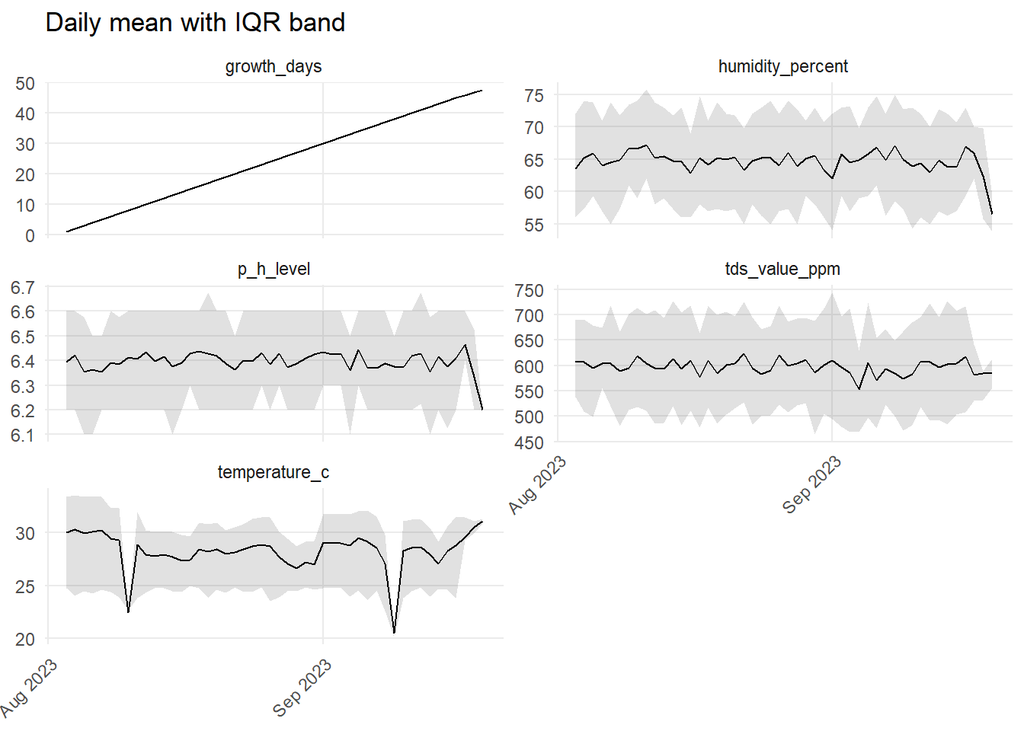

```r
df %>%
  pivot_longer(-c(date, plant_id), names_to = "variable", values_to = "value") %>%
  group_by(variable, date) %>%
  summarise(
    mean = mean(value, na.rm = TRUE),
    p25  = quantile(value, 0.25, na.rm = TRUE),
    p75  = quantile(value, 0.75, na.rm = TRUE),
    .groups = "drop"
  ) %>%
  arrange(variable, date) %>%
  ggplot(aes(date, mean)) +
  geom_ribbon(aes(ymin = p25, ymax = p75), alpha = 0.15) +
  geom_line() +
  facet_wrap(~ variable, scales = "free_y", ncol = 2) +
  scale_x_date(date_breaks = "1 month", date_labels = "%b %Y") +
  labs(x = NULL, y = NULL, title = "Daily mean with IQR band") +
  theme_minimal() +
  theme(axis.text.x = element_text(angle = 45, hjust = 1),
        panel.grid.minor = element_blank())
```

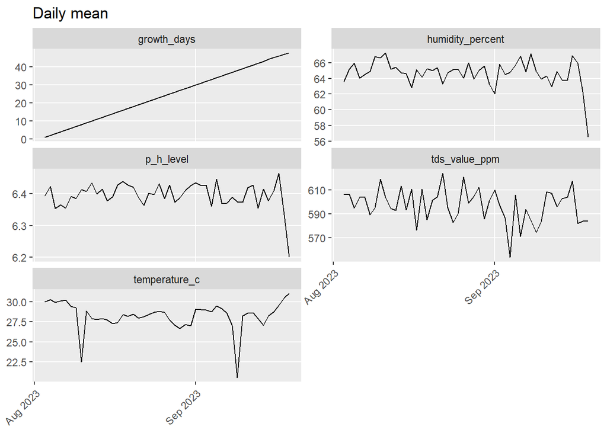

```r
df %>%
  pivot_longer(-c(date, plant_id), names_to = "variable", values_to = "values") %>%
  group_by(variable, date) %>%
  summarise(mean = mean(values)) %>%
  arrange(variable, date) %>%
  ggplot(aes(x = date, y = mean)) +
  geom_line() +
  facet_wrap(~ variable, scales = "free_y", ncol = 2) +
  scale_x_date(date_breaks = "1 month", date_labels = "%b %Y") +
  labs(x = NULL, y = NULL, title = "Daily mean") +
  # theme_minimal() +
  theme(axis.text.x = element_text(angle = 45, hjust = 1),
        panel.grid.minor = element_blank())
```

Scatterplots (check correlation)

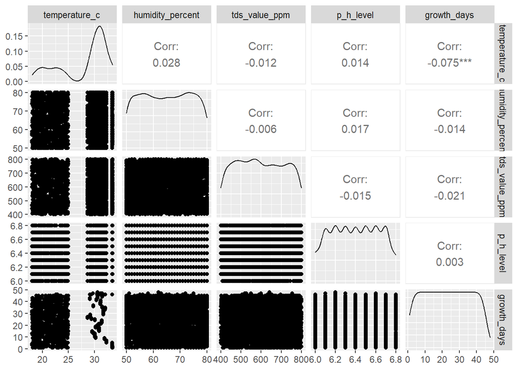

```r
df %>% select(where(is.numeric)) %>%
  ggpairs(progress = FALSE,
          upper = list(continuous = wrap("cor", method = "pearson")),
          diag = list(continuous = "densityDiag"),
          lwer = list(continuous = wrap("points", alpha = 0.4, size = 0.7))

  )
```

# 3.5 Form hypotheses

Does higher humidity improve growth?

Are weekly growth patterns consistent?

Is there seasonality in the data?